# Analysing Sentences Backbone Communities

Published

November 26, 2025

```r
source(here::here("scripts", "paths_and_packages.R"))
p_load(see, kableExtra, DT)

metadata_jstor <- read_rds(file.path(
  jstor_data_path,
  "jstor_constellate_merged_metadata.rds"
)) %>%
  filter(
    refined_sub_type == "research-article",
    languages == "eng",
    publication_year < 2010,
    to_keep,
  ) %>%
  select(
    id = url,
    journal = is_part_of,
    title,
    authors = creators_string,
    year = publication_year,
    ID_Art = id_wos_matched
  ) %>%
  mutate(url = str_c("https://", id)) |>
  arrange(year)

# same for scopus metadata
metadata_scopus <- read_rds(file.path(
  elsevier_data_path,
  "scopus_economics_articles.rds"
)) %>%
  mutate(
    year = as.integer(str_sub(prism_cover_date, 1, 4)),
    url = str_c("https://doi.org/", prism_doi)
  ) %>%
  filter(
    full_text == TRUE,
    subtype_description == "Article",
    year < 2010
  ) %>%
  select(
    id = scopus_id,
    title = dc_title,
    authors = dc_creator,
    journal = prism_publication_name,
    year,
    url,
    ID_Art = id_wos_matched
  )

metadata <- bind_rows(metadata_jstor, metadata_scopus) |>
  filter(!is.na(year) & !is.na(title))

sentences_dataset <- open_dataset(
  file.path(
    data_path,
    "sentences_intertemporal_cluster_min_sample_1.feather"
  ),
  format = "feather"
)

sentences <- sentences_dataset %>%
  filter(between(year, 1900, 2009)) %>%
  select(-year) %>%
  collect() %>%
  inner_join(metadata, by = "id") %>%
  arrange(id, sentence_id)

setDT(sentences)

rm(metadata, metadata_jstor, metadata_scopus)

backbone_network <- read_rds(file.path(
  data_path,
  "backbone_network_of_sentences_clusters_min_sample_1.rds"
)) |>
  filter(window != "2010-2019") # we don't have sentences from 2010 onward

list_clusters <- sentences %>%
  pull(backbone_community) %>%
  unique() |>
  sort()
```

```r
tokens <- extract_ngrams(
  sentences[, .(
    sentence,
    window,
    HDBSCAN_cluster,
    backbone_community
  )],
  ngrams = 2L,
  grouping_cols = c(
    "HDBSCAN_cluster",
    "backbone_community",
    "window"
  ),
  text_col = "sentence",
)

tokens_count_hdbscan_cluster <- compute_tf_idf(
  tokens,
  token_col = "token",
  document_col = c("backbone_community", "HDBSCAN_cluster", "window")
)

# Top tf-idf terms
top_terms_hdbscan_cluster <- tokens_count_hdbscan_cluster[order(-tf_idf)][
  corpus_tf > 20,
  head(.SD, 15),
  by = .(backbone_community, HDBSCAN_cluster, window)
]

# Labels per decade
labels_hdbscan_cluster <- tokens_count_hdbscan_cluster[order(-tf_idf)][
  corpus_tf > 20,
  head(.SD, 5),
  by = .(backbone_community, HDBSCAN_cluster, window)
]

labels_hdbscan_cluster <- labels_hdbscan_cluster[,
  .(label_hdbscan_cluster = paste0(token, collapse = ", ")),
  by = .(backbone_community, HDBSCAN_cluster, window)
]

labels_hdbscan_cluster[,
  label_hdbscan_cluster := paste0(
    backbone_community,
    "_",
    HDBSCAN_cluster,
    "_",
    window,
    ": ",
    label_hdbscan_cluster
  ) # we save the backbonne community number to see difference in top terms depending on kmean cluster
]

sentences <- merge(
  sentences,
  labels_hdbscan_cluster,
  all.x = TRUE,
  by = c("backbone_community", "HDBSCAN_cluster", "window")
)
```

```r
tfidf_mean_community <- tokens_count_hdbscan_cluster[
  corpus_tf > 50,
  .(mean_tf_idf = mean(tf_idf)),
  by = .(token, backbone_community)
][order(-mean_tf_idf)]

# Top tf-idf terms
top_terms_cluster <- tfidf_mean_community[,
  head(.SD, 20),
  by = backbone_community
]

# Get top 4 tf-idf tokens per cluster
labels_backbone_community <- tfidf_mean_community[,
  head(.SD, 4),
  by = backbone_community
][, .(backbone_community, token)]
labels_backbone_community <- labels_backbone_community[,
  .(label_backbone_community = paste0(token, collapse = ", ")),
  by = backbone_community
]
labels_backbone_community[,
  label_backbone_community := paste0(
    str_extract(backbone_community, "\\d+$"),
    ": ",
    label_backbone_community
  )
]

sentences <- merge(
  sentences,
  labels_backbone_community,
  all.x = TRUE,
  by = "backbone_community"
)
```

```r
# Adding references
sentences_art <- sentences[
  !is.na(ID_Art),
  .N,
  .(id, HDBSCAN_cluster, window, backbone_community, ID_Art)
]
setnames(sentences_art, "N", "nb_sentence")

data_ref <- open_dataset(
  here::here(wos_data_path, "all_ref.parquet"),
  format = "parquet"
)
refs <- data_ref %>%
  filter(ID_Art %in% unique(sentences_art$ID_Art)) %>%
  distinct(ID_Art, ItemID_Ref, Annee, Nom, Revue_Abbrege) %>%
  collect()

top_refs <- sentences_art %>%
  left_join(refs, by = "ID_Art", relationship = "many-to-many") %>%
  filter(ItemID_Ref != 0) %>%
  group_by(
    HDBSCAN_cluster,
    window,
    backbone_community,
    ItemID_Ref,
    nb_sentence
  ) %>%
  summarise(absolute_cluster_cit = n(), .groups = "drop") %>%
  mutate(weighted_cluster_cit = absolute_cluster_cit * nb_sentence) %>%
  arrange(
    backbone_community,
    HDBSCAN_cluster,
    window,
    desc(weighted_cluster_cit)
  ) %>%
  group_by(backbone_community, HDBSCAN_cluster, window) %>%
  slice_head(n = 20) %>%
  ungroup() %>%
  filter(weighted_cluster_cit > 1) %>%
  left_join(
    refs %>% distinct(ItemID_Ref, Nom, Annee, Revue_Abbrege),
    by = "ItemID_Ref",
    relationship = "many-to-many"
  ) %>%
  distinct(
    backbone_community,
    HDBSCAN_cluster,
    window,
    ItemID_Ref,
    absolute_cluster_cit,
    weighted_cluster_cit,
    .keep_all = TRUE
  ) %>%
  mutate(
    absolute_cit = sum(absolute_cluster_cit),
    all_sentences = sum(nb_sentence),
    weighted_cit = absolute_cit * all_sentences,
    .by = c(ItemID_Ref, backbone_community)
  )

top_refs_without_id <- sentences_art %>%
  left_join(refs, by = "ID_Art", relationship = "many-to-many") %>%
  filter(ItemID_Ref == 0 & Annee != 0 & Nom != "") %>%
  group_by(backbone_community, HDBSCAN_cluster, window, Nom, Annee) %>%
  mutate(
    absolute_cluster_cit = n(),
    weighted_cluster_cit = absolute_cluster_cit * nb_sentence
  ) %>%
  filter(weighted_cluster_cit > 1) %>%
  distinct(
    ID_Art,
    backbone_community,
    HDBSCAN_cluster,
    window,
    .keep_all = TRUE
  ) %>%
  arrange(
    backbone_community,
    HDBSCAN_cluster,
    window,
    desc(weighted_cluster_cit)
  ) %>%
  group_by(backbone_community, HDBSCAN_cluster, window) %>%
  slice_head(n = 20) %>%
  ungroup() %>%
  select(
    backbone_community,
    HDBSCAN_cluster,
    window,
    Nom,
    Annee,
    Revue_Abbrege,
    nb_sentence,
    absolute_cluster_cit,
    weighted_cluster_cit
  ) %>%
  distinct(
    backbone_community,
    HDBSCAN_cluster,
    window,
    Nom,
    Annee,
    .keep_all = TRUE
  ) %>%
  mutate(
    absolute_cit = sum(absolute_cluster_cit),
    all_sentences = sum(nb_sentence),
    weighted_cit = absolute_cit * all_sentences,
    .by = c(Nom, Annee, Revue_Abbrege, backbone_community)
  )

rm(refs)
```

```r
# Here, we find the sentences the closest to "rational" and "rationality" per kmean cluster
# We would then be able to extract the closest per backbone community later on
top_sentences_rationality <- sentences %>%
  select(
    id,
    sentence_id,
    sentence,
    similarity = similarity_rv,
    year,
    window,
    backbone_community,
    HDBSCAN_cluster
  ) %>%
  group_by(HDBSCAN_cluster, window) %>%
  slice_max(similarity, n = 20) %>%
  ungroup() %>%
  mutate(similarity = round(similarity, 3))
```

```r
# Here, we find the sentences the closest to the centroid of the hdbscan cluster.
# The embedding of the sentence is in embedding; the centroid of the cluster is in centroid. We just need to calculate the distance for each row:
sentences[,
  similarity_hdbscan_centroid := map2_dbl(
    embedding,
    centroid,
    ~ {
      num <- sum(.x * .y)
      den <- sqrt(sum(.x * .x)) * sqrt(sum(.y * .y))
      if (den == 0) NA_real_ else num / den
    }
  )
]

# optional: round similarity for display
sentences[,
  similarity_hdbscan_centroid := round(similarity_hdbscan_centroid, 3)
]

# Select the top 20 sentences for each backbone community
top_sentences_hdbscan_cluster_centroid <- sentences[, .(
  id,
  sentence_id,
  sentence,
  backbone_community,
  HDBSCAN_cluster,
  window,
  similarity_hdbscan_centroid
)]
top_sentences_hdbscan_cluster_centroid <- top_sentences_hdbscan_cluster_centroid[order(
  -similarity_hdbscan_centroid
)][,
  head(.SD, 10),
  by = .(backbone_community, HDBSCAN_cluster, window)
]
```

```r
# compute centroid (mean embedding) per backbone_community and attach to sentences,
# then compute cosine similarity of each sentence to its backbone centroid

# 1) centroid per community: bind embeddings into a matrix then colMeans
community_centroids <- sentences[,
  {
    m <- do.call(rbind, embedding) # matrix: rows = sentences in group
    list(backbone_centroid = list(colMeans(m))) # store centroid as a list-column
  },
  by = backbone_community
]

# 2) merge centroids back into sentences (preserve sentence_id order)
sentences <- merge(
  sentences,
  community_centroids,
  by = "backbone_community",
  all.x = TRUE
)
setorder(sentences, id, sentence_id)

# 3) cosine similarity between each sentence embedding and its community centroid
sentences[,
  backbone_centroid_similarity := map2_dbl(
    embedding,
    centroid,
    ~ {
      num <- sum(.x * .y)
      den <- sqrt(sum(.x * .x)) * sqrt(sum(.y * .y))
      if (den == 0) NA_real_ else num / den
    }
  )
]

# optional: round similarity for display
sentences[,
  backbone_centroid_similarity := round(backbone_centroid_similarity, 3)
]

# Select the top 20 sentences for each backbone community
top_sentences_backbone_community_centroid <- sentences[, .(
  id,
  sentence_id,
  sentence,
  backbone_community,
  backbone_centroid_similarity
)]
top_sentences_backbone_community_centroid <- top_sentences_backbone_community_centroid[order(
  -backbone_centroid_similarity
)][,
  head(.SD, 20),
  by = backbone_community
]
```

```r
set.seed(89)
palette_colors <- c(see::see_colors()[1:14],
                    see::oi_colors()[1:7],
                    scico::scico(n = 6, palette = "roma"))

nb_clusters <- sentences %>%
  pull(backbone_community) %>%
  unique() %>%
  length
if(nb_clusters > length(palette_colors)) cli_alert_danger("The number of clusters exceed the number of available colors in the palette. Please extend the palette.")
cluster_colors <- palette_colors[1:nb_clusters]
```

# General Description of the Method

The next visualisations shows the overall network of kmean clusters connected by similarity links, coloured by backbone community.

```r
# # Extract one centroid per HDBSCAN_cluster with data.table
# hdb_centroids <- sentences[,
#   .(
#     centroid = list(colMeans(do.call(rbind, centroid)))
#   ),
#   by = .(cluster_id)
# ]

# # Build centroid matrix (rows = clusters)
# centroid_matrix <- do.call(rbind, hdb_centroids$centroid) |> as.matrix()
# rownames(centroid_matrix) <- hdb_centroids$cluster_id

# # Cosine similarity between HDBSCAN_cluster centroids
# hdb_cosine_sim <- lsa::cosine(t(centroid_matrix))
# colnames(hdb_cosine_sim) <- rownames(
#   hdb_cosine_sim
# ) <- hdb_centroids$cluster_id

window_levels <- sentences %>%
  pull(window) %>%
  unique() %>%
  sort()

# Finding proximity between backbone communities based on their centroids
# # extract node table from g
# nodes_tbl <- backbone_network %>%
#   activate("nodes") %>%
#   as_tibble(.name_repair = "minimal") |>
#   mutate(x = as.integer(factor(window, levels = window_levels)))

# # feature columns in `centroids` (exclude meta cols)
# feat_cols <- setdiff(
#   names(centroids),
#   c(".cluster", "window", "cluster_original_id")
# )

# # 2) average centroid features per intertemporal community (new_cluster)
# comm_centroids <- centroids %>%
#   mutate(cluster_id = 1:n()) %>%
#   left_join(nodes_tbl %>% select(cluster_id, community), by = "cluster_id") %>%
#   group_by(community) %>%
#   summarise(
#     across(all_of(feat_cols), ~ mean(.x, na.rm = TRUE)),
#     .groups = "drop"
#   )

# 3) hierarchical clustering on scaled community-centroid matrix
backbone_centroid_matrix <- do.call(
  rbind,
  community_centroids$backbone_centroid
) |>
  as.matrix()
mat_scaled <- scale(backbone_centroid_matrix) # scale so features comparable
d <- dist(mat_scaled, method = "euclidean")
hc <- hclust(d, method = "average")

# 4) order communities along the dendrogram
comm_levels <- community_centroids$backbone_community[hc$order]

# 5) build a smooth palette so adjacent communities are visually similar
names(cluster_colors) <- comm_levels
```

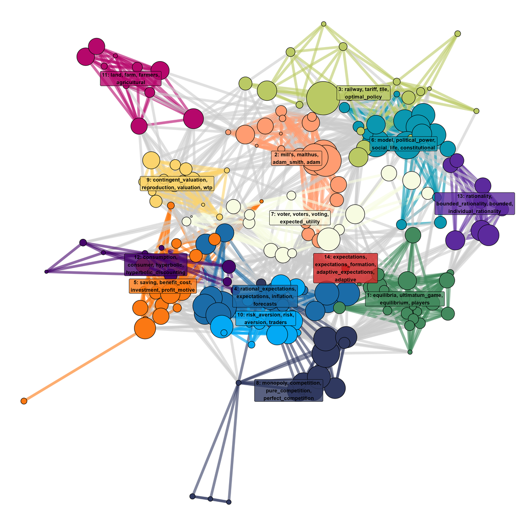

```r
sentences[, size_window := .N, by = window]
sentences[,
  proportion_hdbscan_cluster := .N / size_window,
  by = .(HDBSCAN_cluster, window)
]
backbone_network <- backbone_network %>%
  activate("nodes") %>%
  left_join(
    sentences %>%
      distinct(
        cluster_id,
        HDBSCAN_cluster,
        backbone_community,
        label_hdbscan_cluster,
        label_backbone_community,
        proportion_hdbscan_cluster
      ),
    by = "cluster_id"
  )

backbone_network <- backbone_network %>%
  activate("edges") %>%
  mutate(
    community_from = .N()[["community"]][from],
    community_to = .N()[["community"]][to],
    edge_community = if_else(
      community_from == community_to,
      community_from,
      NA_character_
    ),
    edge_community = factor(edge_community, levels = comm_levels)
  )

# compute layout and community centroids
set.seed(89)
layout <- ggraph::create_layout(backbone_network, layout = "fr")

community_average <- layout %>%
  as_tibble() %>%
  group_by(community) %>%
  summarize(
    x = mean(x, na.rm = TRUE),
    y = mean(y, na.rm = TRUE),
    .groups = "drop"
  ) %>%
  left_join(
    layout %>% as_tibble() %>% distinct(community, label_backbone_community),
    by = "community"
  )

# plot: edges coloured by edge_community when endpoints share same community, otherwise grey
backbone_network_plot <- ggraph(layout) +
  geom_edge_link(
    aes(colour = edge_community),
    alpha = 0.6,
    width = 2,
    show.legend = FALSE
  ) +
  geom_node_point(
    aes(fill = community, size = proportion_hdbscan_cluster),
    show.legend = FALSE,
    shape = 21
  ) +
  geom_label(
    data = community_average,
    aes(
      x = x,
      y = y,
      label = str_wrap(label_backbone_community, 30),
      fill = community
    ),
    size = 3,
    fontface = "bold",
    alpha = 0.8,
    show.legend = FALSE
  ) +
  scale_edge_width(range = c(0.2, 3)) +
  scale_size_continuous(range = c(1, 25)) +
  labs(edge_width = "Avg similarity") +
  scale_edge_color_manual(values = cluster_colors, na.value = "grey80") +
  scale_fill_manual(values = cluster_colors) +
  theme_void()

ggsave(
  here("pictures", "backbone_communities_network.png"),
  backbone_network_plot,
  units = "cm",
  width = 30,
  height = 30,
  dpi = 300
)

knitr::include_graphics(here("pictures", "backbone_communities_network.png"))
```

```r
p_load(ggiraph)

set.seed(89)
backbone_network_ggiraph_plot <- ggraph(layout) +
  geom_edge_link(
    aes(colour = edge_community),
    alpha = 0.6,
    width = 2,
    show.legend = FALSE
  ) +
  # interactive node points: tooltip = label_hdbscan_cluster, data_id = cluster_id
  geom_point_interactive(
    aes(
      x = x,
      y = y,
      fill = community,
      size = proportion_hdbscan_cluster,
      tooltip = str_c(
        label_hdbscan_cluster,
        "\nPeriod:",
        window,
        "\nProportion of sentences in window: ",
        round(proportion_hdbscan_cluster * 100, 2),
        "%"
      ),
      data_id = cluster_id
    ),
    show.legend = FALSE,
    shape = 21
  ) +
  scale_size_continuous(range = c(1, 20)) +
  labs(edge_width = "Avg similarity") +
  scale_edge_color_manual(values = cluster_colors, na.value = "grey80") +
  scale_fill_manual(values = cluster_colors) +
  theme_void()

# create interactive girafe object with sensible hover/tooltip styling
girafe_obj <- ggiraph::girafe(
  ggobj = backbone_network_ggiraph_plot,
  width_svg = 16,
  height_svg = 10,
  options = list(
    ggiraph::opts_selection(type = "single"),
    ggiraph::opts_zoom(min = 1, max = 12), # wheel to zoom, drag to pan
    ggiraph::opts_toolbar(position = "topright")
  )
)

girafe_obj
```

[interactive chart not shown]

The next visualisation takes the same nodes and edges but repositions the nodes in a temporal layout, with time on the x-axis and communities stacked on the y-axis. It allows to see how backbone communities evolve over time.

```r
# per-window equally spaced y to avoid overlap
nodes_pos <- backbone_network %>%
    activate("nodes") %>%
    as_tibble(.name_repair = "minimal") |>
    mutate(x = as.integer(factor(window, levels = window_levels))) |>
  group_by(window) %>%
  arrange(desc(community), .by_group = TRUE) %>%
  mutate(
    n_in_window = n(),
    y = ifelse(n_in_window == 1, 0, seq(-1, 1, length.out = n_in_window))
  ) %>%
  ungroup()

# distribute nodes vertically within each (community, window) cell to avoid overlap
# compute per-(community,x) offsets without calling seq() on a vector
# compute required band per community (max nodes in any x for that community)
comm_band <- nodes_pos %>%
  mutate(community = factor(community, levels = comm_levels)) %>%
  group_by(community, x) %>%
  summarise(n_in_cell = n(), .groups = "drop") %>%
  group_by(community) %>%
  summarise(
    max_in_column = max(n_in_cell, na.rm = TRUE),
    .groups = "drop"
  ) %>%
  arrange(community) %>%
  mutate(
    max_in_column = pmax(max_in_column, 1L),
    pad = 0.7, # vertical padding between community bands
    band = max_in_column + pad # total vertical band height for the community
  ) %>%
  mutate(
    baseline = cumsum(lag(band, default = 0)) + band / 2 # center y for each community band
  ) %>%
  select(community, band, baseline)

# assign nodes within their community/x band
nodes_pos <- nodes_pos %>%
  mutate(community = factor(community, levels = comm_levels)) %>%
  left_join(comm_band, by = "community") %>%
  group_by(community, x) %>%
  arrange(window, cluster_id, .by_group = TRUE) %>%
  mutate(
    n_in_cell = n(),
    # centered offsets inside the community band; works for n_in_cell == 1 as well
    offset = (row_number() - 0.5) * band / n_in_cell - band / 2,
    y = baseline + offset
  ) %>%
  ungroup() %>%
  select(cluster_id, x, y, community)

# join positions into the graph nodes (match keys exactly)
temporal_backbone_network <- backbone_network %>%
  activate("nodes") %>%
  left_join(nodes_pos, by = c("cluster_id", "community"))

# compute label positions for communities (uses comm_band and layout from above)
community_label_positions <- comm_band %>%
  left_join(
    layout %>% as_tibble() %>% distinct(community, label_backbone_community),
    by = "community"
  ) %>%
  arrange(match(community, comm_levels)) %>%
  mutate(label = str_wrap(label_backbone_community, 40))

temporal_network_plot <- ggraph(
  temporal_backbone_network,
  layout = "manual",
  x = x,
  y = y
) +
  geom_edge_link(
    aes(colour = edge_community),
    alpha = 0.5,
    show.legend = FALSE,
    width = 2
  ) +
  geom_label(
    aes(
      x = x,
      y = y,
      label = cluster_id,
      fill = community,
      size = proportion_hdbscan_cluster
    ),
    label.padding = unit(0.12, "lines"),
    show.legend = FALSE,
    alpha = 0.9
  ) +
  scale_fill_manual(values = cluster_colors) +
  scale_edge_color_manual(values = cluster_colors, na.value = "grey80") +
  scale_x_continuous(
    breaks = seq_along(window_levels),
    labels = window_levels
  ) +
  # y axis showing community labels at their baseline positions
  scale_y_continuous(
    breaks = community_label_positions$baseline,
    labels = community_label_positions$label,
    expand = expansion(add = c(1, 0.8))
  ) +
  scale_size_continuous(range = c(3, 10)) +
  labs(x = NULL, y = NULL) +
  theme_minimal() +
  theme(
    panel.grid = element_blank(),
    axis.title.y = element_blank(),
    axis.text.y = element_text(size = 8, hjust = 1),
    axis.ticks.y = element_line(color = "grey50"),
    axis.line.y = element_line(color = "grey50"),
    axis.line.x = element_line(color = "grey50"),
    axis.ticks.x = element_line(color = "grey50"),
    axis.text.x = element_text(angle = 45, hjust = 1, vjust = 1, size = 9)
  )

ggsave(
  here("pictures", "temporal_network_plot.png"),
  temporal_network_plot,
  units = "cm",
  width = 30,
  height = 30,
  dpi = 300
)
```

```r
temporal_network_ggiraph_plot <- ggraph(
  temporal_backbone_network,
  layout = "manual",
  x = x,
  y = y
) +
  geom_edge_link(
    aes(colour = edge_community),
    alpha = 0.5,
    show.legend = FALSE
  ) +
  geom_point_interactive(
    aes(
      x = x,
      y = y,
      fill = community,
      size = proportion_hdbscan_cluster,
      tooltip = str_c(
        label_hdbscan_cluster,
        "\nPeriod:",
        window,
        "\nProportion of sentences in window: ",
        round(proportion_hdbscan_cluster * 100, 2),
        "%"
      ),
      data_id = cluster_id
    ),
    show.legend = FALSE,
    shape = 21,
    alpha = 0.9
  ) +
  scale_fill_manual(values = cluster_colors) +
  scale_edge_color_manual(values = cluster_colors, na.value = "grey80") +
  scale_x_continuous(
    breaks = seq_along(window_levels),
    labels = window_levels
  ) +
  # y axis showing community labels at their baseline positions
  scale_y_continuous(
    breaks = community_label_positions$baseline,
    labels = community_label_positions$label,
    expand = expansion(add = c(0.9, 0.9))
  ) +
  scale_size_continuous(range = c(2, 15)) +
  labs(x = NULL, y = NULL) +
  theme_minimal() +
  theme(
    panel.grid = element_blank(),
    axis.title.y = element_blank(),
    axis.text.y = element_text(size = 10, hjust = 1),
    axis.ticks.y = element_line(color = "grey50"),
    axis.line.y = element_line(color = "grey50"),
    axis.line.x = element_line(color = "grey50"),
    axis.ticks.x = element_line(color = "grey50"),
    axis.text.x = element_text(angle = 45, hjust = 1, vjust = 1, size = 9)
  )

# create interactive girafe object with sensible hover/tooltip styling
girafe_obj_time <- ggiraph::girafe(
  ggobj = temporal_network_ggiraph_plot,
  width_svg = 16,
  height_svg = 10,
  options = list(
    ggiraph::opts_selection(type = "single"),
    opts_tooltip(use_fill = TRUE),
    ggiraph::opts_zoom(min = 1, max = 12), # wheel to zoom, drag to pan
    ggiraph::opts_toolbar(position = "topright")
  )
)

girafe_obj_time
```

[interactive chart not shown]

## Description of the clusters: a reader’s guide

A series of indicators are produced for each clusters. Here are some explanations on how to read them.

### Header summary

**Note**

**What this shows**: size, time span, and main sources of the cluster.  
**How to read**:  
- **Sentences and share**: number of sentences in this cluster and its share of all analysed sentences.  
- **Period**: first and last window where this cluster appears.  
- **Recurring authors/journals**: most frequent contributors by sentence count.  
**Notes**: counts are sentence-level. Long papers can contribute many sentences.

### Top TF-IDF terms describing the community

**Tip**

**What this shows**: words or two-word phrases most specific to this intertemporal backbone community over the full period, in comparison to all other backbone communities.  
**How to read**: higher TF-IDF = greater within-cluster distinctiveness. Compare terms within this table.  
**Use**: quick topic fingerprint.  
**Caution**: This is not an “absolute” TF-IDF: to take into account the fact that more recent periods have more sentences, we average TF-IDF calculated at the window level.

### Top TF-IDF terms by kmean cluster

**Tip**

**What this shows**: the kmean cluster’s distinctive vocabulary.  
**How to read**: compare kmean clusters within the same backbone community to see terms that appear or fade.  
**Use**: detect shifts in focus, methods, or cases across time, as well as diversity within a backbone community.

### Distribution of sentences over time

**Note**

**What this shows**: yearly counts of sentences in this cluster.  
**How to read**: bars = activity level. Peaks = years with more writing on this theme.  
**Caution**: absolute counts, not shares. Later years may have more total publishing.

### Closest sentences from “rationality” and “rational” embeddings within the backbone community

**Note**

### Closest sentences to the backbone community centroid

**Note**

### Closest sentences to the kmean cluster centroids

**Tip**

### Top articles (most sentences) of the backbone community

**Note**

**What this shows**: works contributing the most sentences to this cluster.  
**Columns**: **Number sentences** and **Work Similarity**.  
— **Number sentences**: volume contributed by the work.  
— **Word Similarity**: mean of the cosine similarity to “rationality”/“rational” for that work’s sentences in this cluster.  
**How to read**: Most representative articles of the cluster. Worth clicking on the link to see more about what the article is about. Often a good way to understand how it talks about rationality.

### Top articles (most sentences) of each kmean cluster

**Note**

**What this shows**: same as above, but split by kmean cluster.  
**How to read**: see which articles contribute to which kmean clusters within the backbone community

### Most cited references in the backbone community

**Note**

**What this shows**: the references most often cited by the articles that contribute sentences to this community.

**Columns**  
- **First Author / Year / Journal**: metadata from the reference list.  
- **Citation by article**: number of *distinct articles in this cluster* that cite the reference.  
- **Citation by sentence**: **Citation by article** weighted by how many sentences those citing articles contribute to the cluster (higher = the reference is cited by more central articles in this cluster).

**How to read**: prefer **Citation by sentence** to identify anchors of the cluster; use **Citation by article** to see breadth of citing articles.

**Caveats**  
- The second table lists references *without stable IDs*. This helps recovering books but may be inaccurate.  
- Weighting captures cluster centrality of the *citing articles*, not the number of in-text mentions.  
- Abbreviated journal names may vary.

### Most cited references in each kmean clusters

**Tip**

**What this shows**: decade-level leaders by the same two indicators. **How to read**: compare decades and clusters in same decate to see which references anchor the community at different times.

### Column legend

- **Sentence**: quoted sentence.
- **Title**: clickable article title.
- **Year**: publication year.
- **Journal**: outlet.
- **Authors**: as listed.
- **Words Similarity**: cosine similarity to the embeddings of “rational”/“rationality”.
- **Centroid Similarity**: cosine similarity to the cluster’s centroid.
- **Distance to centroid**: distance to the kmean cluster’s centroid.
- **Number sentences**: sentences from that work in this cluster.

### General cautions

- Similarity values lie in [0,1]. Near-top differences can still matter.
- TF-IDF is comparative within this dataset.
- All counts reflect the top-1% sentences set used here.

# Description of the Clusters

```r
for (cluster in list_clusters) {
  cluster_data <- sentences %>%
    arrange(window) |>
    filter(backbone_community == !!cluster) %>%
    mutate(title = glue("<a href='{url}' target='_blank'>{title}</a>"))

  cluster_name <- cluster_data %>%
    pull(label_backbone_community) %>%
    unique

  hdbscan_clusters <- cluster_data %>%
    distinct(HDBSCAN_cluster, window, cluster_id)

  # extracting the first year and last year of the community
  window <- c(
    first(unique(cluster_data$window)) %>% str_extract("^\\d{4}"),
    last(unique(cluster_data$window)) %>% str_extract("\\d{4}$")
  )

  ################ Beginning of the template ######################
  cat(sprintf("  \n## Intertemporal cluster _%s_ \n\n", cluster_name))

  ############# General Info ##################
  cat(paste0(
    "  \nThe cluster gathers ",
    nrow(distinct(cluster_data, sentence_id, id)),
    " sentences from our corpus. It represents ",
    round(
      nrow(distinct(cluster_data, id, sentence_id)) /
        nrow(distinct(sentences, id, sentence_id)) *
        100,
      2
    ),
    "% of all the sentences selected over the whole period.\n"
  ))

  cat(paste0(
    "\nThe community exists from ",
    window[1],
    " to ",
    window[2],
    ". \n\n"
  ))

  recurring_authors <- cluster_data %>%
    filter(!is.na(authors)) %>%
    select(authors, id) %>%
    separate_longer_delim(authors, delim = ", ") %>%
    # unnest(authors) %>%
    add_count(authors, name = "nb_sentences") %>%
    distinct(authors, id, nb_sentences) %>%
    add_count(authors, name = "nb_articles") %>%
    distinct(authors, nb_sentences, nb_articles) %>%
    slice_max(order_by = nb_sentences, n = 15)
  cat(paste0(
    "The most recurring authors are ",
    paste0(
      recurring_authors$authors,
      " (",
      recurring_authors$nb_sentences,
      " sentences; ",
      recurring_authors$nb_articles,
      " articles)",
      collapse = ", "
    ),
    ".\n\n"
  ))

  recurring_journals <- cluster_data %>%
    select(journal, id) %>%
    add_count(journal, name = "nb_sentences") %>%
    distinct(journal, id, nb_sentences) %>%
    add_count(journal, name = "nb_articles") %>%
    distinct(journal, nb_sentences, nb_articles) %>%
    slice_max(order_by = nb_sentences, n = 6)
  cat(paste0(
    "The most recurring journals are ",
    paste0(
      recurring_journals$journal,
      " (",
      recurring_journals$nb_sentences,
      " sentences; ",
      recurring_journals$nb_articles,
      " articles)",
      collapse = ", "
    ),
    ".\n\n"
  ))

  ############# TF-IDF ##################
  cat("\n### Top TF-IDF terms describing the community\n\n")
  # Extracting top terms in general and for window
  top_terms_cluster %>%
    filter(backbone_community == !!cluster) %>%
    select(token, mean_tf_idf) %>%
    kbl(col.names = c("Token", "TF-IDF")) %>%
    kable_styling(
      bootstrap_options = c("striped", "condensed"),
      font_size = 15
    ) %>%
    print()

  if (nrow(hdbscan_clusters) > 1) {
    cat(
      "\n### Top TF-IDF terms describing the different k-means clusters\n\n"
    )

    for (hdbscan_id in hdbscan_clusters$cluster_id) {
      time_window <- hdbscan_clusters %>%
        filter(cluster_id == hdbscan_id) %>%
        pull(window)

      hdbscan <- hdbscan_clusters %>%
        filter(cluster_id == hdbscan_id) %>%
        pull(HDBSCAN_cluster)

      cat(
        glue(
          "#### Top terms {cluster_data[cluster_id == hdbscan_id,]$label_hdbscan_cluster |> unique()} ({time_window})\n\n"
        ),
        sep = ""
      )

      top_terms_hdbscan_cluster %>%
        filter(window == time_window, HDBSCAN_cluster == hdbscan) %>%
        select(token, tf_idf) %>%
        kbl(col.names = c("Token", "TF-IDF")) %>%
        kable_styling(
          bootstrap_options = c("striped", "condensed"),
          font_size = 11
        ) %>%
        print()
    }
  }

  ############# Distribution sentences ##################
  cat("\n### Distribution of sentences over time \n\n")

  plot(
    cluster_data %>%
      count(year) %>%
      ggplot(aes(x = year, y = n)) +
      geom_bar(stat = "identity") +
      scale_x_continuous(expand = c(0.01, 0), n.breaks = 10) +
      scale_y_continuous(expand = c(0.01, 0)) +
      theme_light(base_size = 20) +
      labs(y = "Number of sentences", x = NULL, title = NULL)
  )

  ####### Top Sentences ###################
  top_sentences_rationality_filtered <- top_sentences_rationality %>%
    filter(backbone_community == !!cluster) %>%
    left_join(distinct(
      cluster_data,
      title,
      journal,
      authors,
      url,
      sentence_id,
      id
    )) %>%
    mutate(title = glue("<a href='{url}' target='_blank'>{title}</a>"))

  top_sentences_hdbscan_cluster_centroid_filtered <- top_sentences_hdbscan_cluster_centroid %>%
    filter(backbone_community == !!cluster) %>%
    left_join(
      distinct(
        cluster_data,
        title,
        year,
        journal,
        authors,
        id,
        sentence_id,
        url
      ),
      by = c("sentence_id", "id")
    ) %>%
    mutate(title = glue("<a href='{url}' target='_blank'>{title}</a>"))

  top_sentences_backbone_community_centroid_filtered <- top_sentences_backbone_community_centroid %>%
    filter(backbone_community == !!cluster) %>%
    left_join(
      distinct(
        cluster_data,
        title,
        year,
        journal,
        authors,
        id,
        sentence_id,
        url
      ),
      by = c("sentence_id", "id")
    ) %>%
    mutate(title = glue("<a href='{url}' target='_blank'>{title}</a>"))

  ############# Top sentences rationality ##################
  cat("\n\n")
  cat(
    "\n### Closest sentence from 'rational' and 'rationality' of the backbone community\n\n"
  )

  top_sentences_rationality_filtered %>%
    slice_max(similarity, n = 20, by = backbone_community) %>%
    select(
      sentence,
      title,
      year,
      journal,
      authors,
      similarity
    ) %>%
    kbl(
      escape = FALSE,
      col.names = c(
        "Sentence",
        "Title",
        "Year",
        "Journal",
        "Authors",
        "Words Similarity"
      )
    ) %>%
    kable_styling(
      bootstrap_options = c("striped", "condensed"),
      font_size = 12
    ) %>%
    column_spec(2, "3.5cm") %>%
    print()
```

```r
  ############# Top sentences centroid ##################
  cat("\n### Closest sentences of the backbone community's centroid\n\n")

  top_sentences_backbone_community_centroid_filtered %>%
    slice_max(backbone_centroid_similarity, n = 15) %>%
    select(
      sentence,
      title,
      year,
      journal,
      authors,
      backbone_centroid_similarity
    ) %>%
    kbl(
      escape = FALSE,
      col.names = c(
        "Sentence",
        "Title",
        "Year",
        "Journal",
        "Authors",
        "Similarity to Backbone Centroid"
      )
    ) %>%
    kable_styling(
      bootstrap_options = c("striped", "condensed"),
      font_size = 13
    ) %>%
    column_spec(2, "3.5cm") %>%
    print()

  if (nrow(hdbscan_clusters) > 1) {
    cat(
      "\n### Closest sentences of each HDBSCAN cluster's centroid composing the backbone community\n\n"
    )

    for (hdbscan_id in unique(cluster_data$cluster_id)) {
      time_window <- hdbscan_clusters %>%
        filter(cluster_id == hdbscan_id) %>%
        pull(window)

      hdbscan <- hdbscan_clusters %>%
        filter(cluster_id == hdbscan_id) %>%
        pull(HDBSCAN_cluster)
      cat(
        glue(
          "#### Top terms {cluster_data[cluster_id == hdbscan,]$label_hdbscan_cluster |> unique()} ({time_window})\n\n"
        ),
        sep = ""
      )

      top_sentences_hdbscan_cluster_centroid_filtered %>%
        filter(window == time_window, HDBSCAN_cluster == hdbscan) %>%
        slice_max(similarity_hdbscan_centroid, n = 10) %>%
        select(
          sentence,
          title,
          year,
          journal,
          authors,
          similarity_hdbscan_centroid
        ) %>%
        kbl(
          escape = FALSE,
          col.names = c(
            "Sentence",
            "Title",
            "Year",
            "Journal",
            "Authors",
            "Similarity to HDSBSCAN Centroid"
          )
        ) %>%
        kable_styling(
          bootstrap_options = c("striped", "condensed"),
          font_size = 12
        ) %>%
        column_spec(2, "3.5cm") %>%
        print()
    }
  }

  ############# Top articles ##################
  cat("\n### Top articles (most sentences) of the backbone cluster\n\n")
  # Extracting top terms in general and for window
  cluster_data |>
    mutate(
      mean_similarity = mean(similarity_rv) %>% round(3),
      n = n(),
      .by = id
    ) %>%
    distinct(
      title,
      year,
      journal,
      authors,
      n,
      mean_similarity
    ) |>
    slice_max(n, n = 15, with_ties = FALSE) %>%
    kbl(
      escape = FALSE,
      col.names = c(
        "Title",
        "Year",
        "Journal",
        "Authors",
        "Number sentences",
        "Words Similarity"
      )
    ) %>%
    kable_styling(
      bootstrap_options = c("striped", "condensed"),
      font_size = 13
    ) %>%
    print()

  if (nrow(hdbscan_clusters) > 1) {
    cat(
      "\n### Top articles (most sentences) of the cluster for each time window{.panel-tabset}\n\n"
    )

    for (hdbscan_id in unique(cluster_data$cluster_id)) {
      time_window <- hdbscan_clusters %>%
        filter(cluster_id == hdbscan_id) %>%
        pull(window)

      hdbscan <- hdbscan_clusters %>%
        filter(cluster_id == hdbscan_id) %>%
        pull(HDBSCAN_cluster)
      cat(
        glue(
          "#### Top articles for {cluster_data[cluster_id == hdbscan,]$label_hdbscan_cluster |> unique()} ({time_window})\n\n"
        ),
        sep = ""
      )

      cluster_data %>%
        filter(window == time_window, HDBSCAN_cluster == hdbscan) %>%
        mutate(
          mean_similarity = mean(similarity_rv) %>% round(3),
          n = n(),
          .by = id
        ) %>%
        distinct(
          title,
          year,
          journal,
          authors,
          n,
          mean_similarity
        ) %>%
        slice_max(n, n = 10, with_ties = FALSE) %>%
        kbl(
          escape = FALSE,
          col.names = c(
            "Title",
            "Year",
            "Journal",
            "Authors",
            "Number sentences",
            "Words Similarity"
          )
        ) %>%
        kable_styling(
          bootstrap_options = c("striped", "condensed"),
          font_size = 13
        ) %>%
        print()
    }
  }

  ############## Top References ##################
  cat("\n### Most cited references in the backbone community\n\n")

  top_refs %>%
    filter(backbone_community == cluster) %>%
    distinct(Nom, Annee, Revue_Abbrege, absolute_cit, weighted_cit) %>%
    filter(absolute_cit > 1) |>
    slice_max(weighted_cit, n = 15, with_ties = FALSE) %>%
    kbl(
      escape = FALSE,
      col.names = c(
        "First Author",
        "Year",
        "Journal",
        "Citation by article",
        "Citation by sentence"
      )
    ) %>%
    kable_styling(
      bootstrap_options = c("striped", "condensed"),
      font_size = 12
    ) %>%
    print()

  top_refs_without_id %>%
    filter(backbone_community == cluster) %>%
    distinct(Nom, Annee, Revue_Abbrege, absolute_cit, weighted_cit) %>%
    filter(absolute_cit > 1) |>
    slice_max(weighted_cit, n = 15, with_ties = FALSE) %>%
    kbl(
      escape = FALSE,
      col.names = c(
        "First Author",
        "Year",
        "Journal",
        "Citation by article",
        "Citation by sentence"
      )
    ) %>%
    kable_styling(
      bootstrap_options = c("striped", "condensed"),
      font_size = 12
    ) %>%
    print()

  if (nrow(hdbscan_clusters) > 1) {
    cat("\n### Most cited references per kmean clusters\n\n")

    for (hdbscan_id in unique(cluster_data$cluster_id)) {
      time_window <- hdbscan_clusters %>%
        filter(cluster_id == hdbscan_id) %>%
        pull(window)

      hdbscan <- hdbscan_clusters %>%
        filter(cluster_id == hdbscan_id) %>%
        pull(HDBSCAN_cluster)

      top_ref_cluster <- top_refs %>%
        filter(window == time_window, HDBSCAN_cluster == hdbscan) %>%
        distinct(
          Nom,
          Annee,
          Revue_Abbrege,
          absolute_cluster_cit,
          weighted_cluster_cit
        ) %>%
        slice_max(weighted_cluster_cit, n = 10, with_ties = FALSE)
```

```r
      top_ref_without_id_cluster <- top_refs_without_id %>%
        filter(window == time_window, HDBSCAN_cluster == hdbscan) %>%
        distinct(
          Nom,
          Annee,
          Revue_Abbrege,
          absolute_cluster_cit,
          weighted_cluster_cit
        ) %>%
        slice_max(weighted_cluster_cit, n = 10, with_ties = FALSE)

      if (nrow(top_ref_cluster) != 0 | nrow(top_ref_without_id_cluster) != 0) {
        cat(
          glue(
            "#### Most cited references for {cluster_data[cluster_id == hdbscan,]$label_hdbscan_cluster |> unique()} ({time_window})\n\n"
          ),
          sep = ""
        )
        if (nrow(top_ref_cluster) > 0) {
          top_ref_cluster %>%
            kbl(
              escape = FALSE,
              col.names = c(
                "First Author",
                "Year",
                "Journal",
                "Citation by article",
                "Citation by sentence"
              )
            ) %>%
            kable_styling(
              bootstrap_options = c("striped", "condensed"),
              font_size = 12
            ) %>%
            print()
        }

        if (nrow(top_ref_without_id_cluster) > 0) {
          top_ref_without_id_cluster %>%
            kbl(
              escape = FALSE,
              col.names = c(
                "First Author",
                "Year",
                "Journal",
                "Citation by article",
                "Citation by sentence"
              )
            ) %>%
            kable_styling(
              bootstrap_options = c("striped", "condensed"),
              font_size = 12
            ) %>%
            print()
        }
      }
    }
  }
}
```

## Intertemporal cluster *1: equilibria, ultimatum_game, equilibrium, players*

The cluster gathers 55606 sentences from our corpus. It represents 20.52% of all the sentences selected over the whole period.

The community exists from 1950 to 2009.

The most recurring authors are Battigalli P. (302 sentences; 9 articles), Vincent P. Crawford (216 sentences; 23 articles), Larry Samuelson (209 sentences; 24 articles), Drew Fudenberg (200 sentences; 23 articles), Jean Tirole (195 sentences; 41 articles), Eric Maskin (171 sentences; 23 articles), Dilip Abreu (169 sentences; 10 articles), B. Douglas Bernheim (166 sentences; 23 articles), Philip J. Reny (160 sentences; 9 articles), Philippe Jehiel (149 sentences; 20 articles), Adam Brandenburger (141 sentences; 7 articles), Robert Sugden (139 sentences; 15 articles), Faruk Gul (137 sentences; 14 articles), Mordecai Kurz (133 sentences; 8 articles), Güth W. (132 sentences; 26 articles).

The most recurring journals are Games and Economic Behavior (4211 sentences; 839 articles), Journal of Economic Theory (3900 sentences; 958 articles), Econometrica (3516 sentences; 649 articles), Journal of Economic Behavior and Organization (3029 sentences; 753 articles), Economic Theory (2367 sentences; 602 articles), The Review of Economic Studies (1952 sentences; 496 articles).

### Top TF-IDF terms describing the community

| Token | TF-IDF |
| --- | --- |
| equilibria | 0.0085130 |
| ultimatum_game | 0.0068783 |
| equilibrium | 0.0068407 |
| players | 0.0068078 |
| player | 0.0067571 |
| ultimatum | 0.0067549 |
| game | 0.0057790 |
| ultimatum_bargaining | 0.0055907 |
| nash | 0.0049020 |
| games | 0.0044759 |
| median_voter | 0.0044498 |
| voter’s | 0.0041373 |
| strategies | 0.0040366 |
| ultimatum_games | 0.0040202 |
| strategy | 0.0037871 |
| bidders | 0.0037407 |
| beliefs | 0.0036161 |
| nash_equilibrium | 0.0035675 |
| electoral | 0.0035451 |
| agents | 0.0034597 |

### Top TF-IDF terms describing the different k-means clusters

#### Top terms 1_0_1950-1959: bargaining, players, game, player, zeuthen (1950-1959)

| Token | TF-IDF |
| --- | --- |
| bargaining | 0.0118633 |
| players | 0.0096630 |
| game | 0.0093738 |
| player | 0.0085263 |
| zeuthen | 0.0067597 |
| games | 0.0063622 |
| strategy | 0.0058547 |
| minimax | 0.0057424 |
| nash’s | 0.0045877 |
| opponent | 0.0043054 |
| nash | 0.0040673 |
| rational_player | 0.0040298 |
| rational_players | 0.0038408 |
| bargains | 0.0035996 |
| bargain | 0.0033204 |

#### Top terms 1_0_1960-1969: bargaining, game, players, games, player (1960-1969)

| Token | TF-IDF |
| --- | --- |
| bargaining | 0.0084135 |
| game | 0.0072916 |
| players | 0.0072586 |
| games | 0.0054319 |
| player | 0.0053438 |
| game_theory | 0.0048722 |
| game_situations | 0.0047413 |
| rationality_postulates | 0.0039808 |
| strategy | 0.0038421 |
| prisoner’s_dilemma | 0.0036915 |
| prisoner’s | 0.0035988 |
| bargainers | 0.0034296 |
| bargaining_power | 0.0034147 |
| strategies | 0.0030425 |
| concessions | 0.0029014 |

#### Top terms 1_1_1970-1979: agents, agent, agent’s, incentive, agent’s_preferences (1970-1979)

| Token | TF-IDF |
| --- | --- |
| agents | 0.0099825 |
| agent | 0.0091858 |
| agent’s | 0.0071313 |
| incentive | 0.0040643 |
| agent’s_preferences | 0.0034879 |
| contracts | 0.0032900 |
| incentive_compatibility | 0.0030101 |
| information | 0.0027018 |
| contingent_claims | 0.0024874 |
| compatibility | 0.0024041 |
| beliefs | 0.0022175 |
| revelation | 0.0020224 |
| preferences | 0.0020007 |
| expended | 0.0019491 |
| expected_utility | 0.0019190 |

#### Top terms 1_0_1970-1979: equilibrium, game, players, player, strategy (1970-1979)

| Token | TF-IDF |
| --- | --- |
| equilibrium | 0.0088791 |
| game | 0.0076608 |
| players | 0.0056676 |
| player | 0.0050703 |
| strategy | 0.0049274 |
| games | 0.0043499 |
| strategies | 0.0043407 |
| nash | 0.0041713 |
| equilibria | 0.0040339 |
| game_theory | 0.0035793 |
| payoff | 0.0033885 |
| strategic | 0.0027979 |
| nash_equilibrium | 0.0024516 |
| disequilibrium | 0.0020680 |
| optimal | 0.0019617 |

#### Top terms 1_1_1980-1989: agents, agent, agent’s, incentive_compatible, incentive (1980-1989)

| Token | TF-IDF |
| --- | --- |
| agents | 0.0106947 |
| agent | 0.0103073 |
| agent’s | 0.0061487 |
| incentive_compatible | 0.0051661 |
| incentive | 0.0049521 |
| beliefs | 0.0044520 |
| bayesian | 0.0041904 |
| incentive_compatibility | 0.0035616 |
| expected_utility | 0.0035072 |
| contract | 0.0033252 |
| contracts | 0.0032481 |
| information | 0.0029780 |
| revelation | 0.0029020 |
| optimal | 0.0026214 |
| compatibility | 0.0026075 |

#### Top terms 1_4_1980-1989: nash, players, player, game, equilibria (1980-1989)

| Token | TF-IDF |
| --- | --- |
| nash | 0.0140618 |
| players | 0.0127015 |
| player | 0.0124790 |
| game | 0.0121141 |
| equilibria | 0.0117513 |
| strategies | 0.0102216 |
| equilibrium | 0.0100817 |
| nash_equilibrium | 0.0097988 |
| strategy | 0.0076704 |
| games | 0.0075266 |
| pure_strategy | 0.0045742 |
| sequential_equilibrium | 0.0039149 |
| nash_equilibria | 0.0038824 |
| subgame | 0.0038165 |
| pure_strategies | 0.0037701 |

#### Top terms 1_5_1980-1989: equilibria, equilibrium, beliefs, sequential_equilibrium, sequential (1980-1989)

| Token | TF-IDF |
| --- | --- |
| equilibria | 0.0258534 |
| equilibrium | 0.0210371 |
| beliefs | 0.0067289 |
| sequential_equilibrium | 0.0053881 |
| sequential | 0.0052729 |
| equilibrium_path | 0.0043510 |
| equilibrium_beliefs | 0.0040642 |
| sequential_equilibria | 0.0039777 |
| disequilibrium | 0.0035142 |
| multiple_equilibria | 0.0034548 |
| model | 0.0030264 |
| equilibrium_exists | 0.0029913 |
| intuitive_criterion | 0.0027427 |
| kreps | 0.0026962 |
| defection | 0.0023056 |

#### Top terms 1_3_1980-1989: player, players, rationalizable, game, strategies (1980-1989)

| Token | TF-IDF |
| --- | --- |
| player | 0.0231137 |
| players | 0.0185432 |
| rationalizable | 0.0156798 |
| game | 0.0111009 |
| strategies | 0.0104800 |
| games | 0.0091326 |
| individually_rational | 0.0087141 |
| nash | 0.0086718 |
| rationalizable_strategies | 0.0071755 |
| strategy | 0.0071374 |
| rationalizability | 0.0069141 |
| rational_player | 0.0066352 |
| individually | 0.0061906 |
| uniquely_rational | 0.0059619 |
| rationality | 0.0058682 |

#### Top terms 1_11_1990-1999: bargaining, ultimatum, ultimatum_game, renegotiation, game (1990-1999)

| Token | TF-IDF |
| --- | --- |
| bargaining | 0.0237180 |
| ultimatum | 0.0212536 |
| ultimatum_game | 0.0119315 |
| renegotiation | 0.0102941 |
| game | 0.0081531 |
| bargaining_game | 0.0078739 |
| games | 0.0066577 |
| players | 0.0057665 |
| bargaining_solution | 0.0055870 |
| ultimatum_games | 0.0055356 |
| player | 0.0055035 |
| nash_bargaining | 0.0052095 |
| ultimatum_bargaining | 0.0049573 |
| nash | 0.0049524 |
| bargaining_games | 0.0044959 |

#### Top terms 1_18_1990-1999: nash, equilibria, nash_equilibrium, equilibrium, pure_strategy (1990-1999)

| Token | TF-IDF |
| --- | --- |
| nash | 0.0227241 |
| equilibria | 0.0213501 |
| nash_equilibrium | 0.0176331 |
| equilibrium | 0.0169146 |
| pure_strategy | 0.0155131 |
| game | 0.0122544 |
| strategy | 0.0117676 |
| strategies | 0.0107885 |
| subgame | 0.0096804 |
| games | 0.0096446 |
| players | 0.0095482 |
| nash_equilibria | 0.0090171 |
| strategy_equilibrium | 0.0090049 |
| strategy_equilibria | 0.0085166 |
| mixed_strategy | 0.0074337 |

#### Top terms 1_15_1990-1999: equilibria, equilibrium, beliefs, multiple_equilibria, equilibrium_beliefs (1990-1999)

| Token | TF-IDF |
| --- | --- |
| equilibria | 0.0320291 |
| equilibrium | 0.0207214 |
| beliefs | 0.0105535 |
| multiple_equilibria | 0.0066907 |
| equilibrium_beliefs | 0.0057873 |
| equilibrium_path | 0.0047968 |
| pooling | 0.0038642 |
| multiple | 0.0036419 |
| separating | 0.0034315 |
| intuitive_criterion | 0.0034174 |
| separating_equilibria | 0.0031302 |
| pooling_equilibria | 0.0027728 |
| sequential_equilibrium | 0.0027574 |
| separating_equilibrium | 0.0027344 |
| sequential | 0.0025028 |

#### Top terms 1_19_1990-1999: players, player, beliefs, bayesian, perfect_bayesian (1990-1999)

| Token | TF-IDF |
| --- | --- |
| players | 0.0234359 |
| player | 0.0206412 |
| beliefs | 0.0151984 |
| bayesian | 0.0139889 |
| perfect_bayesian | 0.0129129 |
| bayesian_equilibrium | 0.0128528 |
| fictitious_play | 0.0091740 |
| game | 0.0087805 |
| strategies | 0.0085152 |
| equilibrium | 0.0075158 |
| nash | 0.0070156 |
| games | 0.0066569 |
| strategy | 0.0066301 |
| player’s | 0.0061249 |
| nash_equilibrium | 0.0057746 |

#### Top terms 1_20_1990-1999: player, players, game, games, rationalizable (1990-1999)

| Token | TF-IDF |
| --- | --- |
| player | 0.0253982 |
| players | 0.0175150 |
| game | 0.0141991 |
| games | 0.0100296 |
| rationalizable | 0.0095876 |
| strategies | 0.0094928 |
| game_theory | 0.0081364 |
| rationalizability | 0.0080986 |
| individually_rational | 0.0066023 |
| rationalizable_strategies | 0.0063187 |
| strategy | 0.0060102 |
| rationality | 0.0057294 |
| payoff | 0.0055571 |
| rational_players | 0.0053171 |
| rational_player | 0.0051649 |

#### Top terms 1_13_1990-1999: agents, agent, agent’s, beliefs, incentive_compatibility (1990-1999)

| Token | TF-IDF |
| --- | --- |
| agents | 0.0124473 |
| agent | 0.0119811 |
| agent’s | 0.0062189 |
| beliefs | 0.0055600 |
| incentive_compatibility | 0.0049945 |
| bayesian | 0.0048333 |
| incentive | 0.0047699 |
| compatibility | 0.0037586 |
| incentive_compatible | 0.0033565 |
| bayesian_incentive | 0.0032916 |
| rational_belief | 0.0028033 |
| contract | 0.0027863 |
| information | 0.0026174 |
| revelation | 0.0025596 |
| contracts | 0.0024651 |

#### Top terms 1_17_2000-2009: nash, equilibria, nash_equilibrium, equilibrium, pure_strategy (2000-2009)

| Token | TF-IDF |
| --- | --- |
| nash | 0.0222791 |
| equilibria | 0.0217135 |
| nash_equilibrium | 0.0176641 |
| equilibrium | 0.0169850 |
| pure_strategy | 0.0168049 |
| strategy | 0.0137426 |
| strategy_equilibria | 0.0120841 |
| strategies | 0.0113876 |
| strategy_equilibrium | 0.0104773 |
| game | 0.0102846 |
| mixed_strategy | 0.0099851 |
| players | 0.0092538 |
| mixed | 0.0084773 |
| subgame | 0.0078908 |
| nash_equilibria | 0.0078887 |

#### Top terms 1_18_2000-2009: players, player, payoff, game, games (2000-2009)

| Token | TF-IDF |
| --- | --- |
| players | 0.0188341 |
| player | 0.0188313 |
| payoff | 0.0101402 |
| game | 0.0095628 |
| games | 0.0085098 |
| payoffs | 0.0065196 |
| strategies | 0.0063085 |
| rationalizable | 0.0056013 |
| strategy | 0.0054950 |
| beliefs | 0.0045867 |
| rationalizability | 0.0040187 |
| game_theory | 0.0038235 |
| player’s | 0.0036824 |
| nash | 0.0034903 |
| rationality | 0.0032895 |

#### Top terms 1_9_2000-2009: incentive_compatibility, incentive, compatibility, agent, incentive_compatible (2000-2009)

| Token | TF-IDF |
| --- | --- |
| incentive_compatibility | 0.0148851 |
| incentive | 0.0136811 |
| compatibility | 0.0114810 |
| agent | 0.0092839 |
| incentive_compatible | 0.0067135 |
| truth_telling | 0.0059210 |
| contract | 0.0050974 |
| compatibility_constraint | 0.0047108 |
| effort_level | 0.0045807 |
| agents | 0.0044412 |
| revelation | 0.0044329 |
| agent’s | 0.0043231 |
| telling | 0.0043199 |
| revelation_principle | 0.0041990 |
| effort | 0.0041769 |

#### Top terms 1_10_2000-2009: agents, agent, beliefs, agent’s, representative_agent (2000-2009)

| Token | TF-IDF |
| --- | --- |
| agents | 0.0215516 |
| agent | 0.0169056 |
| beliefs | 0.0105755 |
| agent’s | 0.0059550 |
| representative_agent | 0.0045297 |
| preferences | 0.0033095 |
| model | 0.0031285 |
| information | 0.0026695 |
| agents_beliefs | 0.0026653 |
| agent’s | 0.0025298 |
| representative | 0.0021369 |
| heterogeneous | 0.0020159 |
| agents_preferences | 0.0019661 |
| probability | 0.0017890 |
| models | 0.0017010 |

#### Top terms 1_1_2000-2009: voting, voters, voter, vote, median_voter (2000-2009)

| Token | TF-IDF |
| --- | --- |
| voting | 0.0185971 |
| voters | 0.0173082 |
| voter | 0.0124829 |
| vote | 0.0071246 |
| median_voter | 0.0044498 |
| election | 0.0042960 |
| voter’s | 0.0041373 |
| median | 0.0038498 |
| candidates | 0.0035956 |
| electoral | 0.0035451 |
| equilibrium | 0.0032400 |
| strategic_voting | 0.0031825 |
| elections | 0.0031392 |
| votes | 0.0030010 |
| candidate | 0.0028863 |

#### Top terms 1_14_2000-2009: equilibria, equilibrium, multiple_equilibria, equilibrium_selection, multiple (2000-2009)

| Token | TF-IDF |
| --- | --- |
| equilibria | 0.0311023 |
| equilibrium | 0.0220020 |
| multiple_equilibria | 0.0096593 |
| equilibrium_selection | 0.0054677 |
| multiple | 0.0047551 |
| model | 0.0040366 |
| equilibrium_model | 0.0033521 |
| competitive_equilibrium | 0.0033267 |
| multiplicity | 0.0026524 |
| unique_equilibrium | 0.0026111 |
| equilibrium_concept | 0.0023266 |
| models | 0.0022202 |
| equilibrium_outcomes | 0.0021530 |
| partial_equilibrium | 0.0021162 |
| section | 0.0019668 |

#### Top terms 1_13_2000-2009: bidders, bidder, auction, seller, buyers (2000-2009)

| Token | TF-IDF |
| --- | --- |
| bidders | 0.0184287 |
| bidder | 0.0157401 |
| auction | 0.0125651 |
| seller | 0.0110709 |
| buyers | 0.0088232 |
| bid | 0.0086762 |
| auctions | 0.0084285 |
| buyer | 0.0081637 |
| bidding | 0.0078100 |
| bids | 0.0071498 |
| sellers | 0.0049653 |
| reserve_price | 0.0048436 |
| seller’s | 0.0043177 |
| equilibrium | 0.0034147 |
| price_auction | 0.0032917 |

#### Top terms 1_8_2000-2009: ultimatum, ultimatum_game, bargaining, game, proposers (2000-2009)

| Token | TF-IDF |
| --- | --- |
| ultimatum | 0.0315296 |
| ultimatum_game | 0.0220448 |
| bargaining | 0.0204352 |
| game | 0.0100705 |
| proposers | 0.0077211 |
| responder | 0.0070946 |
| proposer | 0.0068025 |
| bargaining_game | 0.0066073 |
| responders | 0.0065162 |
| ultimatum_games | 0.0064010 |
| ultimatum_bargaining | 0.0062240 |
| games | 0.0060895 |
| dictator | 0.0054890 |
| players | 0.0053799 |
| dictator_game | 0.0048008 |

### Distribution of sentences over time

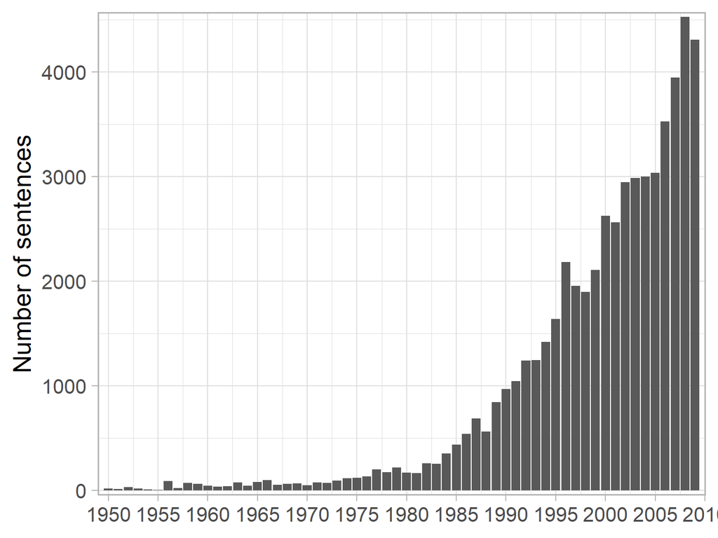

### Closest sentence from ‘rational’ and ‘rationality’ of the backbone community

| Sentence | Title | Year | Journal | Authors | Words Similarity |
| --- | --- | --- | --- | --- | --- |
| RECENT DEVELOPMENTS OF THE CONCEPT OF RATIONALITY The common knowledge discussions in the game theoretic literature have opened up new flexibility in modeling rational interaction, but have also raise… | [Game theory and the history of ideas about rationality: An Introductory Survey](https://doi.org/10.1017/S0266267100005137) | 1993 | Economics and Philosophy | Cudd A.E. | 0.825 |
| Thus, the bound on players’ rationality is more stringent in our paper than in most of the literature. | [Learning in Games by Random Sampling](https://doi.org/10.1006/jeth.2000.2694) | 2001 | Journal of Economic Theory | Friedman J. | 0.823 |
| The theorem states a relation between the rationality of the players and an equilibrium concept and supports the idea that the notion of rationality should not be restricted to expected utility maximi… | [Epistemic conditions for equilibrium in beliefs without independence](https://doi.org/10.1006/jeth.1996.0095) | 1996 | Journal of Economic Theory | Volij O. | 0.818 |
| Elhanan Ben Porath (1997) shows that several rounds of “continuation” are consistent with common certainty of rationality.2 Therefore, rationality alone does not imply the pessimistic and rather unpro… | [Field Centipedes](https://http://www.jstor.org/stable/25592522) | 2009 | The American Economic Review | Ignacio Palacios-Huerta, Oscar Volij | 0.811 |
| If rational players hypothesize a set of deviations Q(#) might occur from the equilibrium #, then each player ought rationally to respond to such deviations. | [Deviations, dynamics, and equilibrium refinements](https://doi.org/10.1006/jeth.1996.0001) | 1996 | Journal of Economic Theory | Rabin M. | 0.810 |
| Now, this line of bounded rationality research is intimately connected to the so-called non-cooperative, rational-choice, or classical game theory, in that a large part of its efforts are directed at … | [The legacy of Herbert Simon in game theory](https://doi.org/10.1016/j.jebo.2002.10.006) | 2004 | Journal of Economic Behavior and Organization | Sent E.M. | 0.809 |
| Decision theory and game theory may have failed to answer the normative question of what constitutes rational behaviour, but they have clarified some of the issues involved, and in the process obtaine… | [Rationality, Learning and Social Norms](https://http://www.jstor.org/stable/2235527) | 1996 | The Economic Journal | Abhinay Muthoo | 0.809 |
| the disposition to be rational if having the chance to act) is not enough to infer the truth of this counterfactual conditional, or to forecast beliefs after a deviation, which is a necessary conditio… | [What happened to the three-legged centipede game?](https://doi.org/10.1111/j.1467-6419.2008.00572.x) | 2009 | Journal of Economic Surveys | Kuechle G. | 0.804 |
| Individual rationality is an integral part of all game-theoretic models, both cooperative and non-cooperative. | [Taxes and subsidies in a polluting and politically powerful industry](https://doi.org/10.1016/j.asieco.2004.05.005) | 2004 | Journal of Asian Economics | Finkelshtain I. | 0.803 |
| By rationality of a player, the authors mean that the action actually chosen by that player maximizes his expected utility, given his beliefs at that state. | [Epistemic conditions for equilibrium in beliefs without independence](https://doi.org/10.1006/jeth.1996.0095) | 1996 | Journal of Economic Theory | Volij O. | 0.803 |
| They model the bounded rationality in two dimensions: the players differ in the level of precision with which they identify best responses as well as in their models of other players. | [An Empirical Model of Strategic Choice with an Application to Coordination Games](https://doi.org/10.1006/game.1998.0678) | 1999 | Games and Economic Behavior | Holt D.J. | 0.803 |
| Some of these may be eliminated by imposing a criterion of “rational” beliefs along the lines of the sequential equilibrium concept in [4]. | [Strategic Behavior in Dynamic Auctions](https://http://www.jstor.org/stable/25054717) | 1993 | Economic Theory | Ruqu Wang | 0.801 |
| INTRODUCTION Received game theory assumes that players are fully rational. | [Limited Foresight May Force Cooperation](https://http://www.jstor.org/stable/2695933) | 2001 | The Review of Economic Studies | Philippe Jehiel | 0.800 |
| We aim to establish criteria to determine if a probability belief of an agent is “rational.” | [On the Structure and Diversity of Rational Beliefs](https://http://www.jstor.org/stable/25054813) | 1994 | Economic Theory | Mordecai Kurz | 0.797 |
| Hence, each player can deduce that some actions are more risky than other actions, and a certain set of prior expectations can be defined as “rational.” | Risk dominance and coordination failures in static games | 1995 | Quarterly Review of Economics and Finance | Straub P.G. | 0.796 |
| We impose two weak constraints on the rationality function: (i) a move is not rational if there is another move that you believe would give you a better payoff; (ii) a move is rational if you believe … | [Grappling with the centipede: Defence of backward induction for bi-terminating games](https://doi.org/10.1017/S0266267100004958) | 1998 | Economics and Philosophy | Rabinowicz W. | 0.795 |
| In the following we describe a model of boundedly rational individuals playing this game. | [Sophisticated imitation in cyclic games](https://doi.org/10.1007/s001910000049) | 2000 | Journal of Evolutionary Economics | Hofbauer J. | 0.793 |
| If rationality is identified with maximizing expected utility, then we can define, in any model, the propositions that some particular player is rational, that all players are rational, that all playe… | [Knowledge, belief and counterfactual reasoning in games](https://doi.org/10.1017/S0266267100004132) | 1996 | Economics and Philosophy | Stalnaker R. | 0.793 |
| As long as it remains obscure how to characterize rational action in games, the rational expectations hypothesis, correctly applied, therefore leaves us as far from determinacy as ever. | [Expecting and Affecting](https://http://www.jstor.org/stable/2663333) | 1989 | Oxford Economic Papers | Michael Bacharach | 0.792 |
| In summary, we argue that there are two characteristics of players that need to be recognized in order to predict behavior when the assumption of common knowledge of rationality fails to hold. | [Depth of reasoning in strategic form games](https://doi.org/10.1016/j.socec.2005.12.003) | 2006 | Journal of Socio Economics | Ohtsubo Y. | 0.791 |
| The model of bounded rationality we study may seem somehow unnatural and isolated from classical problems of game theory. | How to play with a biased coin? | 2002 | Games and Economic Behavior | Gossner O. | 0.791 |
| (S6, Period 4) provide a general model of rationality by expressing a conjecture on players’ rational behaviour. | [Revealing the depth of reasoning in p-beauty contest games](https://doi.org/10.1007/s10683-006-9157-6) | 2008 | Experimental Economics | Sbriglia P. | 0.791 |
| In conventional game theory, related matters have inspired work on the implications of common belief of rationality; see e.g. | [Dynamic psychological games](https://doi.org/10.1016/j.jet.2008.01.004) | 2009 | Journal of Economic Theory | Battigalli P. | 0.791 |

### Closest sentences of the backbone community’s centroid

| Sentence | Title | Year | Journal | Authors | Similarity to Backbone Centroid |
| --- | --- | --- | --- | --- | --- |
| Moreover, even in cases where pure strategy equilibria exist, there may also exist mixed strategy equilibria and these may have different properties, so we may want to understand those properties. | [Voting by successive elimination and strategic candidacy](https://doi.org/10.1006/jeth.2001.2862) | 2002 | Journal of Economic Theory | Dutta B. | 0.891 |
| RECENT DEVELOPMENTS OF THE CONCEPT OF RATIONALITY The common knowledge discussions in the game theoretic literature have opened up new flexibility in modeling rational interaction, but have also raise… | [Game theory and the history of ideas about rationality: An Introductory Survey](https://doi.org/10.1017/S0266267100005137) | 1993 | Economics and Philosophy | Cudd A.E. | 0.890 |
| In this section we propose and discuss three equilibrium concepts. | An intertemporal general equilibrium model with given real wage rates | 2004 | Structural Change and Economic Dynamics | Borissov K. | 0.889 |
| It has long been clear that game-theoretic rationality, as denned by a variety of criteria (e.g. | [Game theory to the rescue?](https://doi.org/10.1093/oxfordjournals.cpe.a035624) | 1994 | Contributions to Political Economy | Rizvi S.A.T. | 0.887 |
| We next present an equilibrium concept somewhat different from the standard Nash equilibrium of a game. | [Morale and the evolution of norms](https://doi.org/10.1016/j.socec.2005.11.029) | 2007 | Journal of Socio Economics | Teraji S. | 0.886 |
| Before formally defining equilibrium, we make some preliminary observations. | [Entrepreneurial finance: Banks versus venture capital](https://doi.org/10.1016/j.jfineco.2007.05.004) | 2008 | Journal of Financial Economics | Winton A. | 0.885 |
| In what follows we will also focus mainly on pure strategy equilibria in the overall game, the detailed analysis of mixed strategy equilibria substantially complicating the presentation of the argumen… | [Leadership and conflict](https://doi.org/10.1016/j.jebo.2006.02.003) | 2007 | Journal of Economic Behavior and Organization | Hamlin A. | 0.884 |
| We discuss the existence of pure strategy equilibria below. | [Participation games: Market entry, coordination, and the beautiful blonde](https://doi.org/10.1016/j.jebo.2005.05.006) | 2007 | Journal of Economic Behavior and Organization | Anderson S.P. | 0.883 |
| Suppose every player choosing a strategy behaves according to the following axioms of rationality which I will call thè`Rationalitythè`Rationality Hypothesis.’’ | [Rationality and coherent theories of strategic behavior](https://doi.org/10.1006/jeth.1996.0073) | 1996 | Journal of Economic Theory | Gul F. | 0.881 |
| Third, we provide a theoretical contribution through complementing their model by discussing two alternative types of equilibria. | [Managing invasive alien species with professional and hobby farmers: Insights from ecological-economic modelling](https://doi.org/10.1016/j.ecolecon.2008.09.006) | 2009 | Ecological Economics | Ceddia M.G. | 0.881 |
| Contrary to the model considered above, pure strategy equilibria do not always exist (see Baye et al. | [Simultaneous inter- and intra-group conflicts](https://http://www.jstor.org/stable/27822558) | 2007 | Economic Theory | Johannes Münster | 0.881 |
| We will demonstrate that for certain parameter values pure strategy equilibria do, now, exist. | [Credit-Worthiness Tests and Interbank Competition](https://http://www.jstor.org/stable/2938210) | 1990 | Econometrica | Thorsten Broecker | 0.880 |
| Consequently, in this paper we take the position that there is no a priori reason to discriminate against equilibria that are not in pure strategies. | [Games with imperfectly observable commitment](https://doi.org/10.1006/game.1997.0524) | 1997 | Games and Economic Behavior | Van Damme E. | 0.879 |
| We first characterize the pure-strategy equilibria. | [Navigating congested networks with variable demand: Experimental evidence](https://doi.org/10.1016/j.joep.2006.06.001) | 2006 | Journal of Economic Psychology | Rapoport A. | 0.879 |
| Throughout the paper we shall restrict ourselves to pure strategy equilibria. | Receiver discretion in signalling models: Information transmission to competing retailers | 1998 | International Journal of Industrial Organization | Albæk S. | 0.878 |
| For the sake for simplicity, we limit our analysis to the characterisation of symmetric equilibria in pure strategy. | [Labour pooling, labour poaching, and spatial clustering](https://doi.org/10.1016/j.regsciurbeco.2005.06.003) | 2006 | Regional Science and Urban Economics | Combes P.P. | 0.878 |

### Closest sentences of each HDBSCAN cluster’s centroid composing the backbone community

| Sentence | Title | Year | Journal | Authors | Similarity to HDSBSCAN Centroid |
| --- | --- | --- | --- | --- | --- |
| It should be emphasized that it is one thing to say that assumptions of complete and certain knowledge on the part of both players seldom hold in any experiment of significant complexity or in any rea… | [Recurrent Objections to the Minimax Strategy](https://http://www.jstor.org/stable/1925456) | 1959 | The Review of Economics and Statistics | Anthony Y. C. Koo | 0.829 |
| If it should appear that a large number of reasonable people will accept some decisions inconsistent with the particular rule that the authors propose, and if their reasons are not random or foolish, … | [Theory of the Reluctant Duelist](https://http://www.jstor.org/stable/1811911) | 1956 | The American Economic Review | Daniel Ellsberg | 0.828 |
| The rational player must address himself to the empirical question of how, in the particular context of his own game, two rational players might achieve tacit coordination of choices, if he is to find… | [For the Abandonment of Symmetry in Game Theory](https://http://www.jstor.org/stable/1927448) | 1959 | The Review of Economics and Statistics | T. C. Schelling | 0.812 |
| In brief, I argued that Zeuthen’s probability calculations and comparisons are irrelevant to a player for the purpose of his selecting a good strategy, a conclusion which follows whether or not ultima… | [Rejoinder on the Bargaining Problem](https://http://www.jstor.org/stable/1055708) | 1958 | Southern Economic Journal | Harvey M. Wagner | 0.807 |
| There, knowledge that one’s opponent is rational under certainty has no immediate bearing on the outcome to be expected from different strategies, for it is known that the opponent himself must act un… | [Theory of the Reluctant Duelist](https://http://www.jstor.org/stable/1811911) | 1956 | The American Economic Review | Daniel Ellsberg | 0.805 |
| That is, the strategy must be chosen so that even under circumstances which yield for this strategy a regret not smaller than under any other circumstances, this regret is not larger than for any othe… | [Rational Behavior, Uncertain Prospects, and Measurable Utility](https://http://www.jstor.org/stable/1907264) | 1950 | Econometrica | Jacob Marschak | 0.802 |
| There is a natural curiosity as to the directions in which the theory of games and its application have been developing; one also wishes to know which of the developments have found widespread agreeme… | [What Has Happened to the Theory of Games](https://http://www.jstor.org/stable/1831502) | 1953 | The American Economic Review | Leonid Hurwicz | 0.797 |
| This assumption seems highly unrealistic, and it is dropped in this paper and replaced by the assumption that each player has a perception of the payoff function of each of the other players; these pe… | [The Determination of Subjective Characteristic Functions in Games with Misperceived Payoff Functions](https://http://www.jstor.org/stable/1905749) | 1956 | Econometrica | R. Duncan Luce, Ernest W. Adams | 0.797 |
| And it may be possible to set up a game in such sanitary fashion, with suppression of identity of players and of all contextual detail, that there is literally no other visible basis for concerting un… | [For the Abandonment of Symmetry in Game Theory](https://http://www.jstor.org/stable/1927448) | 1959 | The Review of Economics and Statistics | T. C. Schelling | 0.794 |
| “23 In nearly all games, if the possibility is considered that the opponent will not be”rational” in the von Neumann-Morgenstern sense, there will be nonminimax strategies which offer the chance of do… | [Theory of the Reluctant Duelist](https://http://www.jstor.org/stable/1811911) | 1956 | The American Economic Review | Daniel Ellsberg | 0.790 |

| Sentence | Title | Year | Journal | Authors | Similarity to HDSBSCAN Centroid |
| --- | --- | --- | --- | --- | --- |
| When the problem is presented in this way, it seems natural to consider it as a problem of bargaining and negotiation which logically should be analysed in the terms of the theory of games. | [Equilibrium in a Reinsurance Market](https://http://www.jstor.org/stable/1909887) | 1962 | Econometrica | Karl Borch | 0.814 |
| If we look at our example as a simple bargaining problem, we can attack it by making assumptions about the behaviour of the two persons. | [Economics and Game Theory](https://http://www.jstor.org/stable/3439376) | 1967 | The Swedish Journal of Economics | Karl Borch | 0.792 |
| Our theory makes use of two classes of rationality postulates in the analysis of game situations. | [Bargaining and Conflict Situations in the Light of a New Approach to Game Theory](https://http://www.jstor.org/stable/1816287) | 1965 | The American Economic Review | John C. Harsanyi | 0.791 |
| Consequently the quantities q1 and q2 in (7.2) and (7.3) represent the two players’ risk limits, defined as the highest subjective probability of a conflict that the 4 We have shown in Harsanyi [7, p.… | [A General Theory of Rational Behavior in Game Situations](https://http://www.jstor.org/stable/1909772) | 1966 | Econometrica | John C. Harsanyi | 0.774 |
| Under our theory, a conflict in this second sense among rational players can arise only in the following cases: 1. | [Bargaining and Conflict Situations in the Light of a New Approach to Game Theory](https://http://www.jstor.org/stable/1816287) | 1965 | The American Economic Review | John C. Harsanyi | 0.770 |
| The model must predict the same actual outcome despite any linear transformations of the players’ utility functions.2 On the basis of these four conditions, Nash came to the remarkable conclusion that… | [A Theory of the Bargaining Process](https://http://www.jstor.org/stable/1816177) | 1965 | The American Economic Review | John G. Cross | 0.767 |
| our rationality postulates yield a decision rule identical to a decision rule for bargaining behavior first proposed by Zeuthen [20], which we call “Zeuthen’s principle.” | [Bargaining and Conflict Situations in the Light of a New Approach to Game Theory](https://http://www.jstor.org/stable/1816287) | 1965 | The American Economic Review | John C. Harsanyi | 0.766 |
| Our analysis of the bargaining problem primarily tries to decide under what conditions a given player can or cannot rationally expect another intelligent player to make him a concession. | [Bargaining and Conflict Situations in the Light of a New Approach to Game Theory](https://http://www.jstor.org/stable/1816287) | 1965 | The American Economic Review | John C. Harsanyi | 0.764 |
| A fully developed theory for these cases would show elements of game and | [Problems in the Cooperative Allocation of Public Expenditures](https://http://www.jstor.org/stable/1883992) | 1969 | The Quarterly Journal of Economics | Martin C. McGuire, Harvey A. Garn | 0.762 |
| Roughly speaking, the principle asserts that the answer depends on the highest risk (i.e., the highest probability of a conflict) each player would be willing to face rather than accept his opponent’s… | [Bargaining and Conflict Situations in the Light of a New Approach to Game Theory](https://http://www.jstor.org/stable/1816287) | 1965 | The American Economic Review | John C. Harsanyi | 0.761 |

| Sentence | Title | Year | Journal | Authors | Similarity to HDSBSCAN Centroid |
| --- | --- | --- | --- | --- | --- |
| is necessary, we shall sketch a situation in which the assumption does not hold and imperfect information about the agent’s action is not valuable, although perfect information is. | [Risk Sharing and Incentives in the Principal and Agent Relationship](https://www.jstor.org/stable/10.2307/3003319) | 1979 | The Bell Journal of Economics | Steven Shavell | 0.786 |
| Given Assumptions 1, 2, 3 and 4, it follows that an admissible representation of the agent’s preferences is (2) U(X)= U E (Xs) where U is an increasing function of its argument. | [A Homiletic Exposition of the Expected Utility Hypothesis](https://http://www.jstor.org/stable/2553568) | 1977 | Economica | Charles Blackorby, Russell Davidson, David Donaldson | 0.780 |
| Each agent is assumed to be able to exercise some degree of control over his strategies. | Toward a theory of optimal economic systems | 1977 | Journal of Comparative Economics | Conn D. | 0.776 |
| In our case, decision have to be made exante and agents are not assumed to have either a priori probabilities or a preference relation from which subjective probabilities can be inferred. | [Competitive Analysis under Complete Ignorance](https://http://www.jstor.org/stable/2525896) | 1975 | International Economic Review | Elisha A. Pazner, David Schmeidler | 0.768 |
| Up to this point homogeneous beliefs are assumed, but in Section 6 this assumption is relaxed to the extent that we allow the agent to be more informed at the time he chooses his action. | [Moral Hazard and Observability](https://www.jstor.org/stable/10.2307/3003320) | 1979 | The Bell Journal of Economics | Bengt Holmström | 0.760 |
| One can, with suitable caution and humility, apply the logic of optimization to aspects of the agent’s choice problem. | [Regulation and Administered Contracts](https://www.jstor.org/stable/10.2307/3003265) | 1976 | The Bell Journal of Economics | Victor P. Goldberg | 0.759 |
| The agent’s preferences among consequences (resp. | Continuity properties of a von Neumann-Morgenstern utility | 1972 | Journal of Economic Theory | Grandmont J. | 0.756 |
| This positive result however relies on a compatibility condition which is imposed on the beliefs of the agents. | Incentives and incomplete information | 1979 | Journal of Public Economics | d’Aspremont C. | 0.753 |
| In this sense the agent can be expected to reveal a utility function v,(.) | Distortion of preferences, income distribution, and the case for a linear income tax | 1977 | Journal of Economic Theory | Kurz M. | 0.752 |
| Observations and Perceived Consequences As we said, the agent does not have complete information about the allocation rule or the actions of the other agents. | [On Quantity Signals and the Foundations of Effective Demand Theory](https://http://www.jstor.org/stable/3439505) | 1977 | The Scandinavian Journal of Economics | Jean-Pascal Benassy | 0.751 |

| Sentence | Title | Year | Journal | Authors | Similarity to HDSBSCAN Centroid |
| --- | --- | --- | --- | --- | --- |
| Given such a conclusion, it is natural to ask whether there exists a strategic equilibrium in which each agent takes the reactions of other agents at least partially into account. | [Informational Equilibrium](https://http://www.jstor.org/stable/1914187) | 1979 | Econometrica | John G. Riley | 0.791 |
| This assumption together with the preceding one leads us to consider what are known in the literature of game theory as Nash equilibrium strategies (Nash, 1951). | [Competitive Bidding for Offshore Petroleum Leases](https://www.jstor.org/stable/10.2307/3003588) | 1978 | The Bell Journal of Economics | Douglas K. Reece | 0.790 |
| Alternatively, there are two pure strategy equilibria, b and c, and yet while both players can guarantee that a is not the social choice, to do so runs the risk of obtaining d which both least prefer. | [The Dilemma of a Paretian Liberal: Some Consequences of Sen’s Theorem](https://http://www.jstor.org/stable/30022961) | 1977 | Public Choice | John Aldrich | 0.786 |
| ON THE RELATIONSHIP BETWEEN NASH AND RATIONAL EXPECTATIONS EQUILIBRIA The notion of a Nash equilibrium in the strategy space may be a natural way to extend the notion of a self-fulfilling equilibrium … | [Market Anticipations, Rational Expectations, and Bayesian Analysis](https://http://www.jstor.org/stable/2526314) | 1978 | International Economic Review | Robert M. Townsend | 0.785 |
| Any particular equilibrium outcome may depend upon the strategic or “bluffing” behavior of agents, the utility of the outcome relative to the perceived subjective costs of “strate- gizing,” and so on. | [The Principle of Unanimity and Voluntary Consent in Social Choice](https://http://www.jstor.org/stable/1837420) | 1977 | Journal of Political Economy | Vernon L. Smith | 0.782 |
| The game theoretic formulation makes it clear, however, that other behavioral assumptions can lead to other solutions. | Innovation and regulation | 1974 | Journal of Public Economics | Bailey E.E. | 0.776 |
| For, given the assumption on the basis of which the individuals choose their strategies, if a strategy is weakly dominated, then any strategy n-tuple in which this strategy figures will not constitute… | [On a Difficulty in the Analysis of Strategic Voting](https://http://www.jstor.org/stable/1913904) | 1978 | Econometrica | Manimay Sengupta | 0.774 |
| An equilibrium or a solution to the game is defined over the set of these decision rules, which depend on knowledge of earlier actions of rivals and correct expectations of the way rivals will act in … | [Preempting an Alert Rival: Strategic Timing of the First Plant by Analysis of Sophisticated Rivalry](https://www.jstor.org/stable/10.2307/3003344) | 1979 | The Bell Journal of Economics | David P. Rutenberg, Ram C. Rao | 0.771 |
| They suggested that situations in which some will gain and some will lose be transformed into a “game” in which the general payoff distribution is known but the specific payoff to each individual is n… | [Probabilistic Compensation Criteria](https://http://www.jstor.org/stable/1880801) | 1972 | The Quarterly Journal of Economics | A. Mitchell Polinsky | 0.769 |
| Another point we must not leave out of consideration is the fact that the automatic forces of the economic mechanism lead to correct results only if the rules of the game on which this automatic actio… | [The Origins of Contradictions in Our Economy and the Path to Their Solution](https://http://www.jstor.org/stable/4379411) | 1970 | Eastern European Economics | Ferenc Jánossy, Czaba L. Köhalmi | 0.766 |

| Sentence | Title | Year | Journal | Authors | Similarity to HDSBSCAN Centroid |
| --- | --- | --- | --- | --- | --- |
| As discussed earlier, an agent’s observed decision in any period t is not assumed to always equal its optimal choice in that period. | The origin of predictable dynamic behavior | 1989 | Journal of Economic Behavior and Organization | Heiner R. | 0.811 |
| It is also assumed that yt is known to all agents before they decide on their own actions at time t. Denote by xt the ’ We are very grateful to Richard Barnett and two anonymous referees for helpful c… | [Dynamic Inconsistency, Rational Expectations, and Optimal Government Policy](https://http://www.jstor.org/stable/1913514) | 1984 | Econometrica | Brian Hillier, James M. Malcomson | 0.811 |
| The principal’s level of expected utility is strictly greater when he and the agent contract with symmetric beliefs about the random state of nature than it is when the contract cannot be arranged unt… | Optimal incentive contracts with multiple agents | 1984 | Journal of Economic Theory | Demski J. | 0.808 |
| This implication can be avoided by making the preferences of the agent stochastic (compare LUCAS [1980]). | [On the Efficacy of Fiscal Policy](https://http://www.jstor.org/stable/20075620) | 1986 | Annales d’Économie et de Statistique | Jürgen Eichberger | 0.798 |
| Second, the authors essentially point out for their two-state example that although the structure of the first-best contract described in Proposition 1 does not depend upon the principal’s beliefs, th… | Limited liability contracts between principal and agent | 1983 | Journal of Economic Theory | Sappington D. | 0.797 |
| This finding is a straightforward consequence of the fact that when the principal and agent share the same (perfect or imperfect) state information, the agent can always be held to his reservation lev… | Optimal incentive contracts with multiple agents | 1984 | Journal of Economic Theory | Demski J. | 0.789 |
| Conclusion It is certainly not surprising that as we weaken the condition representing the effect of the agent’s actions, we would have to strengthen the assumptions on the principal’s utility functio… | [Agency Theory and Stochastic Dominance](https://doi.org/10.2307/2330834) | 1982 | Journal of Financial and Quantitative Analysis | Hughes J. | 0.785 |
| The model chosen by the agent to form expectations will depend critically upon the cost of obtaining information, his prior assessments of the likelihood of competing models, and on the potential loss… | [Information Gathering and Expectation Formation under Model Uncertainty](https://http://www.jstor.org/stable/1058764) | 1987 | Southern Economic Journal | Jeffrey C. Fuhrer | 0.783 |
| Now we allow for uncertainty and recognize that the k-th agent’s preferences among actions will reflect his tastes, his expectations and his attitude toward risk. | Money and transaction costs under uncertainty | 1985 | European Journal of Political Economy | Dusansky R. | 0.781 |
| Second, we allow the principal and agent to disagree on the probabilities of the various events as functions of the agent’s action, and more importantly, we allow the principal and the agent to disagr… | The existence of optimal contracts in the principal-agent model | 1987 | Journal of Mathematical Economics | Page F. | 0.780 |

[output not shown]

Title

Year

Journal

Authors

Similarity to HDSBSCAN Centroid

RECENT DEVELOPMENTS OF THE CONCEPT OF RATIONALITY The common knowledge discussions in the game theoretic literature have opened up new flexibility in modeling rational interaction, but have also raised some problems for the traditional account of rationality we have developed in this paper.

[Game theory and the history of ideas about rationality: An Introductory Survey](https://doi.org/10.1017/S0266267100005137)

1993

Economics and Philosophy

Cudd A.E.

0.890

It has long been clear that game-theoretic rationality, as denned by a variety of criteria (e.g.

[Game theory to the rescue?](https://doi.org/10.1093/oxfordjournals.cpe.a035624)

1994

Contributions to Political Economy

Rizvi S.A.T.

0.887

Suppose every player choosing a strategy behaves according to the following axioms of rationality which I will call thè`Rationalitythè`Rationality Hypothesis.’’

[Rationality and coherent theories of strategic behavior](https://doi.org/10.1006/jeth.1996.0073)

1996

Journal of Economic Theory

Gul F.

0.881

First, a sharp notion for the implications of rational behavior must be given for games with small doubts.

Rational behavior with payoff uncertainty

1990

Journal of Economic Theory

Dekel E.

0.873

This brings us to the refinements and some the less obvious problems of rationality in game-theoretic settings.

[Game theory to the rescue?](https://doi.org/10.1093/oxfordjournals.cpe.a035624)

1994

Contributions to Political Economy

Rizvi S.A.T.

0.872